# Import packages

```python
import pandas as pd
import numpy as np
import os
from google.colab import drive
import matplotlib.pyplot as plt
import seaborn as sns
from sklearn.feature_selection import chi2
from functools import reduce
from sklearn.ensemble import RandomForestClassifier
from sklearn.svm import SVC
from sklearn.linear_model import LogisticRegression
from xgboost import XGBClassifier
from sklearn.metrics import f1_score, make_scorer
from sklearn.model_selection import GridSearchCV, RandomizedSearchCV
from sklearn.metrics import plot_confusion_matrix, classification_report
from scipy.stats import chi2_contingency
import numpy as np
import category_encoders
from category_encoders import TargetEncoder
from category_encoders.one_hot import OneHotEncoder
from pickle import dump
import pickle
from sklearn.decomposition import PCA
from sklearn.model_selection import train_test_split
from sklearn.metrics import f1_score, accuracy_score, confusion_matrix


drive.mount('/content/drive')
os.chdir('/content/drive/My Drive/AXA test/multi_class')
```

# Read datasets

- Read datasets of train and test

```python
df_train = pd.read_csv("./train.csv")
df_test = pd.read_csv("test.csv")
df_train.head(10)
```

|  | id | AP | creation_date_answer | situation | ctc | location | gc_id | gc_label | creation_date_global | id_group | ... | fruits_or_vegetables | number_of_fruit | id_group_3 | creation_date_request | hobby | id_group_4 | ville | green_vegetables | vegetable_type | target |
| --- | --- | --- | --- | --- | --- | --- | --- | --- | --- | --- | --- | --- | --- | --- | --- | --- | --- | --- | --- | --- | --- |
| 0 | a46cfa61ea20a | f | 2019-03-13 11:14:42.549 | -1 | NaN | 52 | 70 | G | 2019-01-17 10:50:57.767 | 2d7e206d46ea1 | ... | NaN | -1 | 812a43d710ace | 2019-03-13 11:14:42.549 | football | aa8f4934a31eb | NaN | f | NaN | 0 |
| 1 | c3d0cb8f0c5e2 | f | 2019-03-21 14:27:32.441 | -1 | NaN | 78 | 10 | A | 2018-08-20 05:57:51.038 | 35e96d6848871 | ... | NaN | -1 | 4b59257f24573 | 2019-03-21 14:27:32.441 | football | 6ff9ea9ec85fd | NaN | f | NaN | 1 |
| 2 | 05dfbe0ec3a8b | f | 2019-03-15 17:49:50.67 | -1 | NaN | 70 | 10 | A | 2018-12-20 13:45:51.752 | ffaf8085e383d | ... | NaN | -1 | f1a838f0d194b | 2019-03-15 17:49:50.67 | football | 6a49a0a97b049 | NaN | f | NaN | 0 |
| 3 | 952e869ee1076 | f | 2019-01-07 08:19:29.114 | -1 | f | 84 | 10 | A | 2018-07-21 10:28:49.386 | 5360cf0a40ce3 | ... | NaN | 0 | c3196847d1c14 | 2019-01-07 08:19:29.114 | football | d0dcf1ca1bf04 | NaN | f | NaN | 1 |
| 4 | 5bd0e71b1395b | f | 2019-02-03 17:57:22.926 | -1 | NaN | 29 | 20 | D | 2018-12-07 19:59:26.968 | 126c3211f23fc | ... | NaN | -1 | 70e18c6fe58cd | 2019-02-03 17:57:22.926 | football | b4870b1c8eb42 | NaN | f | NaN | 1 |
| 5 | d68831bf79cde | f | 2019-03-20 12:54:00.834 | -1 | NaN | 32 | 10 | A | 2019-03-18 15:21:12.844 | 66ee828c029a1 | ... | NaN | -1 | ad2af49523d6f | 2019-03-20 12:54:00.834 | football | 6222cd523cb49 | NaN | f | NaN | 0 |
| 6 | acf52b56b11cb | f | 2019-01-17 15:11:08.4 | -1 | NaN | 96 | 30 | C | 2018-11-06 23:41:24.221 | fd3a6d8c2aa45 | ... | NaN | -1 | 0fa277c3e6e76 | 2019-01-17 15:11:08.4 | football | ec8768db88b6b | NaN | f | NaN | 0 |
| 7 | f8a2795043f2f | f | 2019-03-20 11:10:41.106 | -1 | f | 43 | 10 | A | 2017-12-20 16:55:13.666 | 3977f0930bc7f | ... | f | 0 | f7451621f2a0e | 2019-03-20 11:10:41.106 | football | 82c11a326f6b0 | Saint-Étienne | f | NaN | 0 |
| 8 | fc6267843888f | f | 2019-02-20 08:56:19.297 | -1 | f | 50 | 10 | A | 2018-12-09 19:11:24.389 | eaec08a510a99 | ... | f | 0 | d22c50bde8789 | 2019-02-20 08:56:19.297 | football | afeff5743dc2f | NaN | f | NaN | 1 |
| 9 | 5fc9fdf1915db | f | 2019-02-23 08:53:00 | -1 | NaN | 47 | 10 | A | 2018-09-30 07:36:19.419 | 3b135b0691669 | ... | NaN | -1 | fd03965de092f | 2019-02-23 08:53:00 | football | 7c5e6a2b60e90 | NaN | f | NaN | 0 |

10 rows × 24 columns

# Data pre-processing

- We create a dataframe containing : nomber of null values and their percentage in the train dataset, unique values in train test datasets, distinct values for both train and test and common values between train and test.

```python
# Define a dataframe
df_summary = pd.DataFrame(
    columns=[
        "features",
        "null_train_features",
        "percentage_missing_values",
        "unique_values_train",
        "unique_values_test",
        "common_values",
    ]
)

# Store all columns in "features" column
df_summary["features"] = df_test.nunique().index.tolist()

# Get the number of null values in each feature in training dataset
df_summary["null_train_features"] = df_train.iloc[:, :-1].isnull().sum().tolist()

# Get the percentage of missing values in each column
df_summary["percentage_missing_values"] = df_summary.apply(
    lambda x: (x["null_train_features"] / len(df_train)) * 100, axis=1
)

# Get number of unique values in train dataset
df_summary["unique_values_train"] = df_train[df_summary.features].nunique().tolist()

# Get number of unique values in train dataset
df_summary["unique_values_test"] = df_test[df_summary.features].nunique().tolist()

# Get common unique values in train and test dataset
df_summary["common_values"] = df_summary.apply(
    lambda x: len(
        set(df_train[x["features"]].unique()).intersection(
            df_test[x["features"]].unique()
        )
    ),
    axis=1,
)

df_summary
```

|  | features | null_train_features | percentage_missing_values | unique_values_train | unique_values_test | common_values |
| --- | --- | --- | --- | --- | --- | --- |
| 0 | id | 0 | 0.000 | 25000 | 25000 | 0 |
| 1 | AP | 0 | 0.000 | 2 | 2 | 2 |
| 2 | creation_date_answer | 0 | 0.000 | 24278 | 24211 | 564 |
| 3 | situation | 0 | 0.000 | 8 | 8 | 8 |
| 4 | ctc | 15380 | 61.520 | 2 | 2 | 3 |
| 5 | location | 0 | 0.000 | 99 | 99 | 98 |
| 6 | gc_id | 0 | 0.000 | 12 | 12 | 12 |
| 7 | gc_label | 0 | 0.000 | 12 | 12 | 12 |
| 8 | creation_date_global | 0 | 0.000 | 15680 | 15714 | 6845 |
| 9 | id_group | 0 | 0.000 | 15844 | 15900 | 6821 |
| 10 | id_group_2 | 0 | 0.000 | 15675 | 15717 | 6884 |
| 11 | favorite_fruit | 0 | 0.000 | 2 | 2 | 2 |
| 12 | fruit_situation_id | 0 | 0.000 | 22 | 22 | 22 |
| 13 | fruit_situation_label | 1728 | 6.912 | 21 | 21 | 22 |
| 14 | fruits_or_vegetables | 17341 | 69.364 | 2 | 2 | 3 |
| 15 | number_of_fruit | 0 | 0.000 | 9 | 10 | 9 |
| 16 | id_group_3 | 0 | 0.000 | 872 | 858 | 805 |
| 17 | creation_date_request | 0 | 0.000 | 24280 | 24211 | 559 |
| 18 | hobby | 0 | 0.000 | 3 | 3 | 3 |
| 19 | id_group_4 | 0 | 0.000 | 15831 | 15887 | 6815 |
| 20 | ville | 16912 | 67.648 | 564 | 543 | 402 |
| 21 | green_vegetables | 0 | 0.000 | 2 | 2 | 2 |
| 22 | vegetable_type | 24586 | 98.344 | 6 | 6 | 7 |

## Drop duplicate rows

We'll remove all rows that have the same values in all columns expect id feature

```python
# Drop all duplicate row
df_train = df_train.drop_duplicates(subset = df_train.columns.tolist()[1:], keep = 'first')
```

## Missing values

From the df_summary dataframe, we observe that :

- "ctc", "fruits_or_vegetables", "ville" and "vegetable_type" have respectively 15380 (more than 61%), 17341 (more than 69%), 16912 (more than 67%) and 24586 (more than 98%) null values. So we should delete them, because we could have replaced them with the value of the majority class but this can bias the model (more than 60% of null values).

```python
# Drop columns
df_train.drop(
    ["ctc", "fruits_or_vegetables", "ville", "vegetable_type"], axis=1, inplace=True
)
```

```python
# Get unique couple of values (fruit_situation_id, fruit_situation_label)
df_train[["fruit_situation_id", "fruit_situation_label"]].drop_duplicates()
```

|  | fruit_situation_id | fruit_situation_label |
| --- | --- | --- |
| 0 | 120 | jzy |
| 1 | 10 | ae |
| 2 | 200 | ag |
| 7 | 110 | zyrj |
| 8 | 170 | NaN |
| 14 | 50 | hetz |
| 21 | 160 | zht |
| 39 | 100 | jyz |
| 57 | 80 | li |
| 158 | 220 | tej |
| 194 | 130 | dfhj |
| 235 | 20 | wfj |
| 352 | 190 | RG |
| 380 | 180 | fyi |
| 427 | 70 | jwn |
| 727 | 150 | lou |
| 888 | 40 | qg |
| 1053 | 210 | jy |
| 1114 | 30 | KDT |
| 1190 | 90 | lfyi |
| 2224 | 140 | wjy |
| 5427 | 60 | fly |

```python
print(
    "Percentages of each of the four classes that has this null value : ",
    [
        a / b
        for (a, b) in zip(
            df_train[df_train["fruit_situation_label"].isnull()]["target"]
            .value_counts()
            .tolist(),
            df_train["target"].value_counts().tolist(),
        )
    ],
)
```

```
Percentages of each of the four classes that has this null value :  [0.0876117919841007, 0.052177858439201454, 0.050335570469798654, 0.06437768240343347]
```

```python
# drop the fruit_situation_label column
df_train.drop("fruit_situation_label", axis=1, inplace=True)
```

- gc_label is the feature label of gc_id, we should drop one of them

```python
df_train[["gc_id", "gc_label"]].drop_duplicates()
```

|  | gc_id | gc_label |
| --- | --- | --- |
| 0 | 70 | G |
| 1 | 10 | A |
| 4 | 20 | D |
| 6 | 30 | C |
| 12 | 40 | B |
| 14 | 100 | H |
| 32 | 60 | L |
| 39 | 90 | F |
| 43 | 120 | E |
| 60 | 50 | I |
| 110 | 80 | K |
| 5898 | 110 | J |

```python
# drop the gc_id column
df_train.drop("gc_id", axis=1, inplace=True)
```

## Process continuous and categorical feeatures

```python
# Define continuous columns
continuous_features = [
    "creation_date_answer",
    "situation",
    "creation_date_global",
    "number_of_fruit",
    "creation_date_request",
]
```

```python
# Define categorical columns
categorical_features = [
    "AP",
    "location",
    "gc_label",
    "id_group",
    "id_group_2",
    "favorite_fruit",
    "fruit_situation_id",
    "id_group_3",
    "hobby",
    "id_group_4",
    "green_vegetables",
    "target",
]
```

```python
# Get the categorical features from the train dataset
df_categorical_features = df_train[categorical_features].reset_index(drop=True)
df_categorical_features
```

|  | AP | location | gc_label | id_group | id_group_2 | favorite_fruit | fruit_situation_id | id_group_3 | hobby | id_group_4 | green_vegetables | target |
| --- | --- | --- | --- | --- | --- | --- | --- | --- | --- | --- | --- | --- |
| 0 | f | 52 | G | 2d7e206d46ea1 | 36bac09400660 | poire | 120 | 812a43d710ace | football | aa8f4934a31eb | f | 0 |
| 1 | f | 78 | A | 35e96d6848871 | 80a697d593706 | clementine | 10 | 4b59257f24573 | football | 6ff9ea9ec85fd | f | 1 |
| 2 | f | 70 | A | ffaf8085e383d | c309176b96268 | clementine | 200 | f1a838f0d194b | football | 6a49a0a97b049 | f | 0 |
| 3 | f | 84 | A | 5360cf0a40ce3 | 13c1a3597648b | clementine | 10 | c3196847d1c14 | football | d0dcf1ca1bf04 | f | 1 |
| 4 | f | 29 | D | 126c3211f23fc | 7b68e0a456571 | clementine | 10 | 70e18c6fe58cd | football | b4870b1c8eb42 | f | 1 |
| ... | ... | ... | ... | ... | ... | ... | ... | ... | ... | ... | ... | ... |
| 24994 | f | 17 | A | 07d568301bae5 | 8ed90715244e0 | clementine | 160 | 7f9b9fe72ad1b | football | 97de0f5d0b0cf | f | 0 |
| 24995 | f | 93 | A | ecf26c2e00203 | 5f820a5b9c8cd | clementine | 10 | 5918a05e76cfe | football | 0aac6e868db10 | f | 1 |
| 24996 | f | 68 | A | c84066a550a3a | 6532597956225 | clementine | 200 | 50101f6881261 | football | 89c8a90e0ce38 | f | 0 |
| 24997 | f | 78 | D | 98e8126974bad | 8aa3d8d3a97d3 | clementine | 200 | 0f1a3e137c5ea | football | 0157899906f02 | f | 1 |
| 24998 | f | 60 | A | 1707d41f20deb | 8cd910513240b | clementine | 200 | 7232a3a11e532 | football | fbb2e051ded47 | f | 0 |

24999 rows × 12 columns

```python
# Get the continuous features from the train dataset
df_continuous_features = df_train[continuous_features].reset_index(drop=True)
df_continuous_features
```

|  | creation_date_answer | situation | creation_date_global | number_of_fruit | creation_date_request |
| --- | --- | --- | --- | --- | --- |
| 0 | 2019-03-13 11:14:42.549 | -1 | 2019-01-17 10:50:57.767 | -1 | 2019-03-13 11:14:42.549 |
| 1 | 2019-03-21 14:27:32.441 | -1 | 2018-08-20 05:57:51.038 | -1 | 2019-03-21 14:27:32.441 |
| 2 | 2019-03-15 17:49:50.67 | -1 | 2018-12-20 13:45:51.752 | -1 | 2019-03-15 17:49:50.67 |
| 3 | 2019-01-07 08:19:29.114 | -1 | 2018-07-21 10:28:49.386 | 0 | 2019-01-07 08:19:29.114 |
| 4 | 2019-02-03 17:57:22.926 | -1 | 2018-12-07 19:59:26.968 | -1 | 2019-02-03 17:57:22.926 |
| ... | ... | ... | ... | ... | ... |
| 24994 | 2019-03-21 16:50:00 | -1 | 2019-03-16 10:58:47.728 | -1 | 2019-03-21 16:50:00 |
| 24995 | 2019-02-15 21:12:58.495 | -1 | 2018-09-15 09:44:56.995 | -1 | 2019-02-15 21:12:58.495 |
| 24996 | 2019-01-03 10:39:40.683 | -1 | 2018-09-20 13:19:07.214 | 0 | 2019-01-03 10:39:40.683 |
| 24997 | 2019-01-17 12:45:02.132 | -1 | 2018-11-04 17:35:07.482 | 0 | 2019-01-17 12:45:02.132 |
| 24998 | 2019-02-26 09:25:15.449 | -1 | 2018-10-11 14:48:51.208 | 0 | 2019-02-26 09:25:15.449 |

24999 rows × 5 columns

### Add new columns

```python
def process_date(x):
    """
    This function extracts year, month, day, hour, minute, second from a datetime feature
    :param x : datetime columns
    :return a list of extracted year, month, day, hour, minute and second
    """
    return [
        int(x.year),
        int(x.month),
        int(x.day),
        int(x.hour),
        int(x.minute),
        int(x.second),
    ]
```

```python
def add_columns(df, column_, suffix):
    """
    This function add 6 feature : year, month, day, hour, minute,
    second to the dataset and drop the datetime feature

    :param df : input datafrale.
    :param columns_ : the datetime feature.
    :param sufix : suffix we want to add to new column's names.
    :return: final dataset.
    """

    # columns of the new features we want to add
    list_columns = [
        col + suffix
        for col in ["year_", "month_", "day_", "hour_", "minute_", "second_"]
    ]

    # create a new dataframe containing extracted year, month, day, hour, minue and second from column_
    df_date = pd.DataFrame(
        process_date(x) for x in pd.to_datetime(df[column_])
    ).set_axis(list_columns, axis=1)

    # Join the dataframe created with df_continuous_features
    df = pd.concat([df_date, df], axis=1)

    # drop creation_date_answer column
    df.drop(column_, axis=1, inplace=True)

    return df
```

```python
# Extract Year, month, day, hour, minute, second from creation_date_answer column
df_continuous_features = add_columns(
    df_continuous_features, "creation_date_answer", "asr"
)

# Extract Year, month, day, hour, minute, second from creation_date_global column
df_continuous_features = add_columns(
    df_continuous_features, "creation_date_global", "glb"
)

# Extract Year, month, day, hour, minute, second from creation_date_request column
df_continuous_features = add_columns(
    df_continuous_features, "creation_date_request", "rqt"
)
```

```python
df_continuous_features
```

|  | year_rqt | month_rqt | day_rqt | hour_rqt | minute_rqt | second_rqt | year_glb | month_glb | day_glb | hour_glb | minute_glb | second_glb | year_asr | month_asr | day_asr | hour_asr | minute_asr | second_asr | situation | number_of_fruit |
| --- | --- | --- | --- | --- | --- | --- | --- | --- | --- | --- | --- | --- | --- | --- | --- | --- | --- | --- | --- | --- |
| 0 | 2019 | 3 | 13 | 11 | 14 | 42 | 2019 | 1 | 17 | 10 | 50 | 57 | 2019 | 3 | 13 | 11 | 14 | 42 | -1 | -1 |
| 1 | 2019 | 3 | 21 | 14 | 27 | 32 | 2018 | 8 | 20 | 5 | 57 | 51 | 2019 | 3 | 21 | 14 | 27 | 32 | -1 | -1 |
| 2 | 2019 | 3 | 15 | 17 | 49 | 50 | 2018 | 12 | 20 | 13 | 45 | 51 | 2019 | 3 | 15 | 17 | 49 | 50 | -1 | -1 |
| 3 | 2019 | 1 | 7 | 8 | 19 | 29 | 2018 | 7 | 21 | 10 | 28 | 49 | 2019 | 1 | 7 | 8 | 19 | 29 | -1 | 0 |
| 4 | 2019 | 2 | 3 | 17 | 57 | 22 | 2018 | 12 | 7 | 19 | 59 | 26 | 2019 | 2 | 3 | 17 | 57 | 22 | -1 | -1 |
| ... | ... | ... | ... | ... | ... | ... | ... | ... | ... | ... | ... | ... | ... | ... | ... | ... | ... | ... | ... | ... |
| 24994 | 2019 | 3 | 21 | 16 | 50 | 0 | 2019 | 3 | 16 | 10 | 58 | 47 | 2019 | 3 | 21 | 16 | 50 | 0 | -1 | -1 |
| 24995 | 2019 | 2 | 15 | 21 | 12 | 58 | 2018 | 9 | 15 | 9 | 44 | 56 | 2019 | 2 | 15 | 21 | 12 | 58 | -1 | -1 |
| 24996 | 2019 | 1 | 3 | 10 | 39 | 40 | 2018 | 9 | 20 | 13 | 19 | 7 | 2019 | 1 | 3 | 10 | 39 | 40 | -1 | 0 |
| 24997 | 2019 | 1 | 17 | 12 | 45 | 2 | 2018 | 11 | 4 | 17 | 35 | 7 | 2019 | 1 | 17 | 12 | 45 | 2 | -1 | 0 |
| 24998 | 2019 | 2 | 26 | 9 | 25 | 15 | 2018 | 10 | 11 | 14 | 48 | 51 | 2019 | 2 | 26 | 9 | 25 | 15 | -1 | 0 |

24999 rows × 20 columns

## Correlation between variables

In this section, we'll compute the correlation's index of continuous and categorical features :

### a - Continuous features :

```python
df_continuous_features.nunique()
```

```
year_rqt            1
month_rqt           3
day_rqt            31
hour_rqt           24
minute_rqt         60
second_rqt         60
year_glb            9
month_glb          12
day_glb            31
hour_glb           24
minute_glb         60
second_glb         60
year_asr            1
month_asr           3
day_asr            31
hour_asr           24
minute_asr         60
second_asr         60
situation           8
number_of_fruit     9
dtype: int64
```

```python
# drop features with one unique value
drop_feature = ["year_rqt", "year_asr"]
df_continuous_features.drop(drop_feature, axis=1, inplace=True)
```

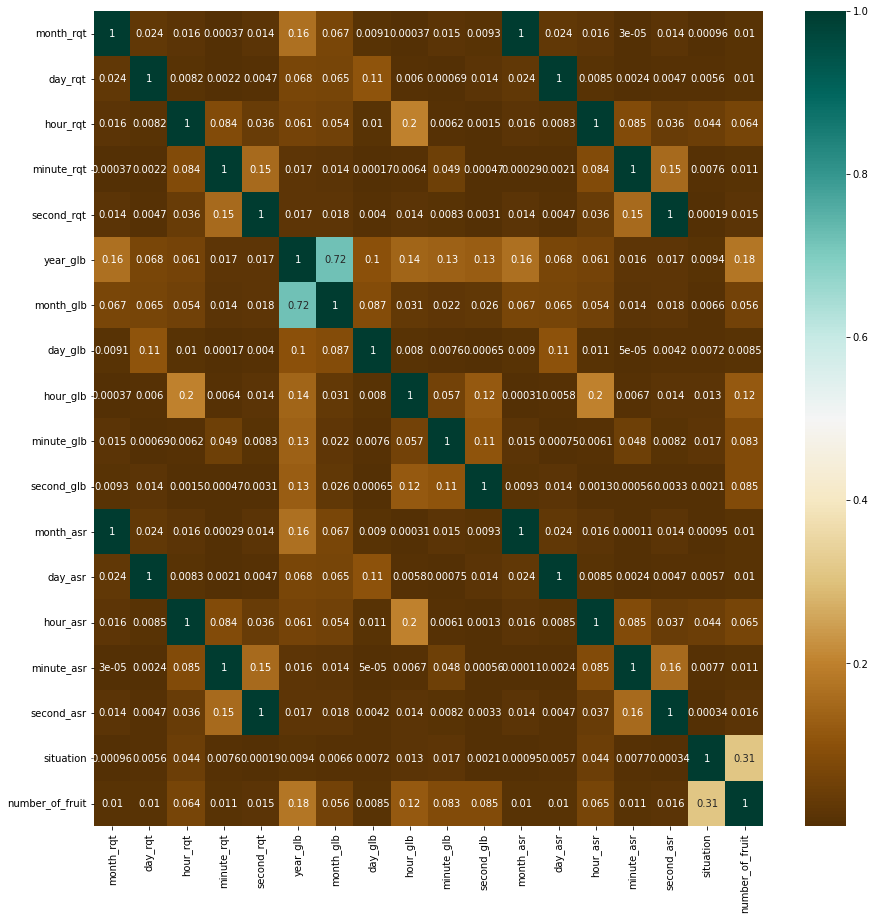

```python
# In this cell, we perform Spearman correlation index between the different
# label columns in order to reduce the Label space dimensionality.


# Create correlation matrix
corr_mat = df_continuous_features.corr(method="spearman").abs()

# Plot the correlation matrix between features
plt.subplots(figsize=(15, 15))
sns.heatmap(data=corr_mat, annot=True, cmap="BrBG")
plt.show()
```

```python
# Select upper triangle of correlation matrix
sup = corr_mat.where(np.triu(np.ones(corr_mat.shape), k=1).astype(np.bool))

# Find labels having a correlation greater or equal to 0.85 (Strong correlation).
to_drop = [column for column in sup.columns if any(sup[column] >= 0.85)]

# Drop correlated columns
df_continuous_features.drop(to_drop, axis=1, inplace=True)
df_continuous_features.head()
```

|  | month_rqt | day_rqt | hour_rqt | minute_rqt | second_rqt | year_glb | month_glb | day_glb | hour_glb | minute_glb | second_glb | situation | number_of_fruit |
| --- | --- | --- | --- | --- | --- | --- | --- | --- | --- | --- | --- | --- | --- |
| 0 | 3 | 13 | 11 | 14 | 42 | 2019 | 1 | 17 | 10 | 50 | 57 | -1 | -1 |
| 1 | 3 | 21 | 14 | 27 | 32 | 2018 | 8 | 20 | 5 | 57 | 51 | -1 | -1 |
| 2 | 3 | 15 | 17 | 49 | 50 | 2018 | 12 | 20 | 13 | 45 | 51 | -1 | -1 |
| 3 | 1 | 7 | 8 | 19 | 29 | 2018 | 7 | 21 | 10 | 28 | 49 | -1 | 0 |
| 4 | 2 | 3 | 17 | 57 | 22 | 2018 | 12 | 7 | 19 | 59 | 26 | -1 | -1 |

```python
df_continuous_features.columns
```

```
Index(['month_rqt', 'day_rqt', 'hour_rqt', 'minute_rqt', 'second_rqt',
       'year_glb', 'month_glb', 'day_glb', 'hour_glb', 'minute_glb',
       'second_glb', 'situation', 'number_of_fruit'],
      dtype='object')
```

### c - Categorical features :

```python
df_categorical_features.iloc[:,:-1]
```

|  | AP | location | gc_label | id_group | id_group_2 | favorite_fruit | fruit_situation_id | id_group_3 | hobby | id_group_4 | green_vegetables |
| --- | --- | --- | --- | --- | --- | --- | --- | --- | --- | --- | --- |
| 0 | f | 52 | G | 2d7e206d46ea1 | 36bac09400660 | poire | 120 | 812a43d710ace | football | aa8f4934a31eb | f |
| 1 | f | 78 | A | 35e96d6848871 | 80a697d593706 | clementine | 10 | 4b59257f24573 | football | 6ff9ea9ec85fd | f |
| 2 | f | 70 | A | ffaf8085e383d | c309176b96268 | clementine | 200 | f1a838f0d194b | football | 6a49a0a97b049 | f |
| 3 | f | 84 | A | 5360cf0a40ce3 | 13c1a3597648b | clementine | 10 | c3196847d1c14 | football | d0dcf1ca1bf04 | f |
| 4 | f | 29 | D | 126c3211f23fc | 7b68e0a456571 | clementine | 10 | 70e18c6fe58cd | football | b4870b1c8eb42 | f |
| ... | ... | ... | ... | ... | ... | ... | ... | ... | ... | ... | ... |
| 24994 | f | 17 | A | 07d568301bae5 | 8ed90715244e0 | clementine | 160 | 7f9b9fe72ad1b | football | 97de0f5d0b0cf | f |
| 24995 | f | 93 | A | ecf26c2e00203 | 5f820a5b9c8cd | clementine | 10 | 5918a05e76cfe | football | 0aac6e868db10 | f |
| 24996 | f | 68 | A | c84066a550a3a | 6532597956225 | clementine | 200 | 50101f6881261 | football | 89c8a90e0ce38 | f |
| 24997 | f | 78 | D | 98e8126974bad | 8aa3d8d3a97d3 | clementine | 200 | 0f1a3e137c5ea | football | 0157899906f02 | f |
| 24998 | f | 60 | A | 1707d41f20deb | 8cd910513240b | clementine | 200 | 7232a3a11e532 | football | fbb2e051ded47 | f |

24999 rows × 11 columns

```python
# Here, we compute Cramer's V association index between categorical features.

def cramers_V(x, y):
    """
    This function computes the cramer's V association index

    :param x : first feature
    :param y : second feature
    :retune: the Cramer's v coeeficient
    """

    # Get the crosstab based on x and y
    crosstab = np.array(pd.crosstab(x, y, rownames=None, colnames=None))

    # Compute the chi-square statistic and
    # p-value for the hypothesis test of independence of
    # the observed frequencies in the contingency table
    chi2 = chi2_contingency(crosstab)[0]
    n = np.sum(crosstab)
    phi2 = chi2 / n
    r, k = crosstab.shape
    phi2corr = max(0, phi2 - ((k - 1) * (r - 1)) / (n - 1))
    rcorr, kcorr = r - ((r - 1) ** 2) / (n - 1), k - ((k - 1) ** 2) / (n - 1)
    return np.sqrt(phi2corr / min((kcorr - 1), (rcorr - 1)))
```

```python
# List of columns
list_columns = df_categorical_features.columns.tolist()

# The correlation matrix : a lower triangular matrix
rows = []

# Loop over all columns and compute cramer's v association index
for i in range(len(list_columns)):
    col = []
    for j in range(i + 1):
        cramers = cramers_V(
            df_categorical_features[list_columns[i]],
            df_categorical_features[list_columns[j]],
        )  # Cramer's V test
        col.append(round(cramers, 2))  # Keeping of the rounded value of the Cramer's V
    col += [0 for _ in range(len(list_columns) - i - 1)]
    rows.append(col)

# Correlation matrix with zeros on the diagoal
matrix_0_diag = np.array(rows)
matrix_0_diag[np.diag_indices_from(matrix_0_diag)] = 0

# sum the lower and upper traingular correlation matrix
assoc_mat = np.array(rows).transpose() + np.array(matrix_0_diag)

# Convert it to dataframe
assoc_mat = pd.DataFrame(
    assoc_mat,
    columns=df_categorical_features.columns,
    index=df_categorical_features.columns,
)
```

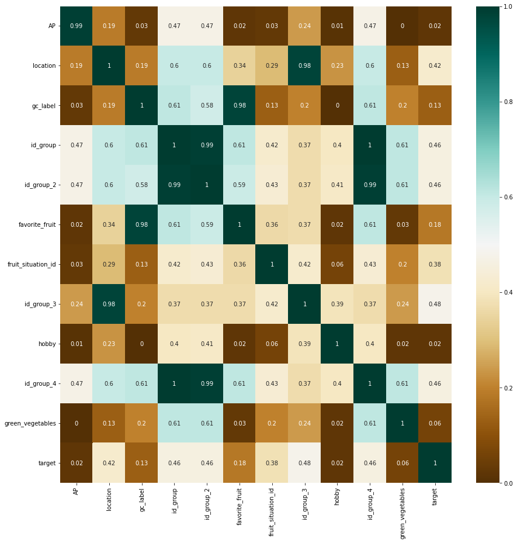

```python
# Plot the correlation matrix between features
plt.subplots(figsize=(15,15))
sns.heatmap(data=assoc_mat, annot=True, cmap="BrBG")
plt.show()
```

```python
# Select upper triangle of association matrix
sup = assoc_mat.where(np.triu(np.ones(assoc_mat.shape), k=1).astype(np.bool))

# Find labels having an association greater or equal to 0.85 (Strong association).
to_drop = [column for column in sup.columns if any(sup[column] >= 0.85)]
to_drop
```

```
['id_group_2', 'favorite_fruit', 'id_group_3', 'id_group_4']
```

```python
# Drop correlated features
df_categorical_features.drop(to_drop, axis=1, inplace=True)
df_categorical_features.head()
```

|  | AP | location | gc_label | id_group | fruit_situation_id | hobby | green_vegetables | target |
| --- | --- | --- | --- | --- | --- | --- | --- | --- |
| 0 | f | 52 | G | 2d7e206d46ea1 | 120 | football | f | 0 |
| 1 | f | 78 | A | 35e96d6848871 | 10 | football | f | 1 |
| 2 | f | 70 | A | ffaf8085e383d | 200 | football | f | 0 |
| 3 | f | 84 | A | 5360cf0a40ce3 | 10 | football | f | 1 |
| 4 | f | 29 | D | 126c3211f23fc | 10 | football | f | 1 |

```python
df_categorical_features.columns
```

```
Index(['AP', 'location', 'gc_label', 'id_group', 'fruit_situation_id', 'hobby',
       'green_vegetables', 'target'],
      dtype='object')
```

## Encode categorical features

In this section, we'll encode categorical features :

- For feature with hight number of unique values, we'll use Target encoding to avoid large sparse matrices : a method that doesn’t add to the dimensionality of the dataset. In our case we have : id_group (with 15844 unique values) and location (with 99 unique values) and fruit_situation_id (with 22 unique values)
- Using target encoding for all categorical features may lead to model overfitting, because of its dependency to the distribution of the target.
- For the rest of the categorical features, we'll use one hot encoding : a representation of categorical variables as binary vectors

### Traget encoding

```python
# Categorical features with high and low frequencies
features_high_frequency = ["id_group", "fruit_situation_id", "location"]
features_low_frequency = ["AP", "gc_label", "hobby", "green_vegetables"]

# Convert type of categorical column to string
df_categorical_features[["fruit_situation_id", "location"]] = df_categorical_features[
    ["fruit_situation_id", "location"]
].astype(str)
```

```python
# Define Target encoder
te_encoder = TargetEncoder()


# Encode features_high_frequency using Target encoding
te_encoded_df = te_encoder.fit_transform(
    df_categorical_features[features_high_frequency], df_categorical_features["target"]
)

# Drop features we just encoded
df_categorical_features.drop(features_high_frequency, axis=1, inplace=True)

# Join the encoded features with the df_categorical_features
df_categorical_features = pd.concat([te_encoded_df, df_categorical_features], axis=1)

df_categorical_features.head()
```

|  | id_group | fruit_situation_id | location | AP | gc_label | hobby | green_vegetables | target |
| --- | --- | --- | --- | --- | --- | --- | --- | --- |
| 0 | 0.185717 | 0.308682 | 0.096916 | f | G | football | f | 0 |
| 1 | 0.963112 | 1.000556 | 0.665245 | f | A | football | f | 1 |
| 2 | 0.082315 | 0.376397 | 0.391165 | f | A | football | f | 0 |
| 3 | 0.669513 | 1.000556 | 0.560606 | f | A | football | f | 1 |
| 4 | 0.985324 | 1.000556 | 0.921260 | f | D | football | f | 1 |

```python
# save the one hot encoding encoder
dump(te_encoder, open('te_encoder.pkl', 'wb'))
```

### One hot encoding

```python
# creating instance of one-hot-encoder
ohe_encoder = OneHotEncoder(use_cat_names=True)

# perform one-hot encoding on features_low_frequency columns
ohe_encoder_df = pd.DataFrame(
    ohe_encoder.fit_transform(df_categorical_features[features_low_frequency])
)

# Drop features we just encoded
df_categorical_features.drop(features_low_frequency, axis=1, inplace=True)

# Join the encoded features with the df_categorical_features
df_categorical_features = pd.concat([ohe_encoder_df, df_categorical_features], axis=1)

df_categorical_features.head()
```

|  | AP_f | AP_t | gc_label_G | gc_label_A | gc_label_D | gc_label_C | gc_label_B | gc_label_H | gc_label_L | gc_label_F | ... | gc_label_J | hobby_football | hobby_volleyball | hobby_noball | green_vegetables_f | green_vegetables_t | id_group | fruit_situation_id | location | target |
| --- | --- | --- | --- | --- | --- | --- | --- | --- | --- | --- | --- | --- | --- | --- | --- | --- | --- | --- | --- | --- | --- |
| 0 | 1 | 0 | 1 | 0 | 0 | 0 | 0 | 0 | 0 | 0 | ... | 0 | 1 | 0 | 0 | 1 | 0 | 0.185717 | 0.308682 | 0.096916 | 0 |
| 1 | 1 | 0 | 0 | 1 | 0 | 0 | 0 | 0 | 0 | 0 | ... | 0 | 1 | 0 | 0 | 1 | 0 | 0.963112 | 1.000556 | 0.665245 | 1 |
| 2 | 1 | 0 | 0 | 1 | 0 | 0 | 0 | 0 | 0 | 0 | ... | 0 | 1 | 0 | 0 | 1 | 0 | 0.082315 | 0.376397 | 0.391165 | 0 |
| 3 | 1 | 0 | 0 | 1 | 0 | 0 | 0 | 0 | 0 | 0 | ... | 0 | 1 | 0 | 0 | 1 | 0 | 0.669513 | 1.000556 | 0.560606 | 1 |
| 4 | 1 | 0 | 0 | 0 | 1 | 0 | 0 | 0 | 0 | 0 | ... | 0 | 1 | 0 | 0 | 1 | 0 | 0.985324 | 1.000556 | 0.921260 | 1 |

5 rows × 23 columns

```python
# save the one hot encoding encoder
dump(ohe_encoder, open('ohe_encoder.pkl', 'wb'))
```

### Merge continuous and categorical features

```python
df_train_last = pd.concat([df_continuous_features, df_categorical_features], axis=1)
```

```python
df_train_last
```

|  | month_rqt | day_rqt | hour_rqt | minute_rqt | second_rqt | year_glb | month_glb | day_glb | hour_glb | minute_glb | ... | gc_label_J | hobby_football | hobby_volleyball | hobby_noball | green_vegetables_f | green_vegetables_t | id_group | fruit_situation_id | location | target |
| --- | --- | --- | --- | --- | --- | --- | --- | --- | --- | --- | --- | --- | --- | --- | --- | --- | --- | --- | --- | --- | --- |
| 0 | 3 | 13 | 11 | 14 | 42 | 2019 | 1 | 17 | 10 | 50 | ... | 0 | 1 | 0 | 0 | 1 | 0 | 0.185717 | 0.308682 | 0.096916 | 0 |
| 1 | 3 | 21 | 14 | 27 | 32 | 2018 | 8 | 20 | 5 | 57 | ... | 0 | 1 | 0 | 0 | 1 | 0 | 0.963112 | 1.000556 | 0.665245 | 1 |
| 2 | 3 | 15 | 17 | 49 | 50 | 2018 | 12 | 20 | 13 | 45 | ... | 0 | 1 | 0 | 0 | 1 | 0 | 0.082315 | 0.376397 | 0.391165 | 0 |
| 3 | 1 | 7 | 8 | 19 | 29 | 2018 | 7 | 21 | 10 | 28 | ... | 0 | 1 | 0 | 0 | 1 | 0 | 0.669513 | 1.000556 | 0.560606 | 1 |
| 4 | 2 | 3 | 17 | 57 | 22 | 2018 | 12 | 7 | 19 | 59 | ... | 0 | 1 | 0 | 0 | 1 | 0 | 0.985324 | 1.000556 | 0.921260 | 1 |
| ... | ... | ... | ... | ... | ... | ... | ... | ... | ... | ... | ... | ... | ... | ... | ... | ... | ... | ... | ... | ... | ... |
| 24994 | 3 | 21 | 16 | 50 | 0 | 2019 | 3 | 16 | 10 | 58 | ... | 0 | 1 | 0 | 0 | 1 | 0 | 0.690548 | 0.728659 | 0.567568 | 0 |
| 24995 | 2 | 15 | 21 | 12 | 58 | 2018 | 9 | 15 | 9 | 44 | ... | 0 | 1 | 0 | 0 | 1 | 0 | 0.690548 | 1.000556 | 1.365714 | 1 |
| 24996 | 1 | 3 | 10 | 39 | 40 | 2018 | 9 | 20 | 13 | 19 | ... | 0 | 1 | 0 | 0 | 1 | 0 | 0.690548 | 0.376397 | 0.396890 | 0 |
| 24997 | 1 | 17 | 12 | 45 | 2 | 2018 | 11 | 4 | 17 | 35 | ... | 0 | 1 | 0 | 0 | 1 | 0 | 0.690548 | 0.376397 | 0.665245 | 1 |
| 24998 | 2 | 26 | 9 | 25 | 15 | 2018 | 10 | 11 | 14 | 48 | ... | 0 | 1 | 0 | 0 | 1 | 0 | 0.185717 | 0.376397 | 0.103314 | 0 |

24999 rows × 36 columns

## Summurise all preprocessing steps

```python
# Processing dataframe
def process_dataset(df):
    """
    This function applies all preporcessing steps on test dataframe :
        - Drop correlated features
        - Drop columns with missing values
        - Encode categorical features with both : Target encoder and one hot encoding

    :param  df: the test dataframe
    :return df after preprocessing
    """

    # Columns after dropping correlated features and ones with missing values
    columns_train = [
        "month_rqt",
        "day_rqt",
        "hour_rqt",
        "minute_rqt",
        "second_rqt",
        "year_glb",
        "month_glb",
        "day_glb",
        "hour_glb",
        "minute_glb",
        "second_glb",
        "situation",
        "number_of_fruit",
        "AP",
        "location",
        "gc_label",
        "id_group",
        "fruit_situation_id",
        "hobby",
        "green_vegetables",
    ]

    # Last columns used for models
    feature_model = [
        "month_rqt",
        "day_rqt",
        "hour_rqt",
        "minute_rqt",
        "second_rqt",
        "year_glb",
        "month_glb",
        "day_glb",
        "hour_glb",
        "minute_glb",
        "second_glb",
        "situation",
        "number_of_fruit",
        "AP_f",
        "AP_t",
        "gc_label_G",
        "gc_label_A",
        "gc_label_D",
        "gc_label_C",
        "gc_label_B",
        "gc_label_H",
        "gc_label_L",
        "gc_label_F",
        "gc_label_E",
        "gc_label_I",
        "gc_label_K",
        "gc_label_J",
        "hobby_football",
        "hobby_volleyball",
        "hobby_noball",
        "green_vegetables_f",
        "green_vegetables_t",
        "id_group",
        "fruit_situation_id",
        "location",
    ]

    # Categorical features with high and low frequencies
    features_high_frequency = ["id_group", "fruit_situation_id", "location"]
    features_low_frequency = ["AP", "gc_label", "hobby", "green_vegetables"]

    # Extract Year, month, day, hour, minute, second from creation_date_answer column
    df = add_columns(df, "creation_date_answer", "asr")

    # Extract Year, month, day, hour, minute, second from creation_date_global column
    df = add_columns(df, "creation_date_global", "glb")

    # Extract Year, month, day, hour, minute, second from creation_date_request column
    df = add_columns(df, "creation_date_request", "rqt")

    # Drop correlated columns and columns wih missing values,
    df = df[columns_train]

    # Convert categorical's feature type to string
    df[["fruit_situation_id", "location"]] = df[
        ["fruit_situation_id", "location"]
    ].astype(str)

    # load Target encoder
    encoder_te = pickle.load(open("te_encoder.pkl", "rb"))

    # load one hot encoder
    encoder_ohe = pickle.load(open("ohe_encoder.pkl", "rb"))

    # Apply Target encoder on features_high_frequency
    X_test_te = encoder_te.transform(df[features_high_frequency])

    # Drop features we just encoded
    df.drop(features_high_frequency, axis=1, inplace=True)

    # Join the encoded features with the df_categorical_features
    df = pd.concat([X_test_te, df], axis=1)

    # Apply the one hot encoder
    X_test_ohe = encoder_ohe.transform(df[features_low_frequency])

    # Join the encoded features with the df_categorical_features
    df = pd.concat([X_test_ohe, df], axis=1)

    return df[feature_model]
```

## Apply PCA

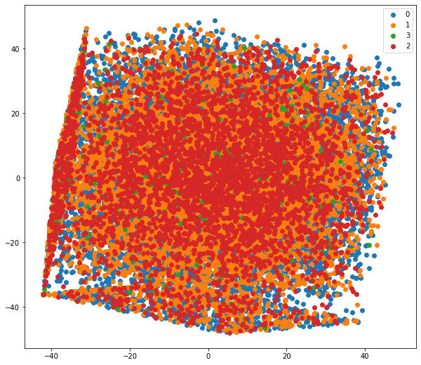

```python
# Let's try to have a visualization of our feature vectors in 2D dimensional space
# obtained after PCA reduction

# Let's perform a dimensionality reduction
coords_2d = PCA(n_components=2).fit_transform(df_train_last.iloc[:, :-1])

fig = plt.figure(figsize=(10, 9))
for categ in df_train_last["target"].unique():
    plt.scatter(
        coords_2d[df_train_last["target"] == categ, 0],
        coords_2d[df_train_last["target"] == categ, 1],
        label=categ,
    )
plt.legend()
plt.show()
```

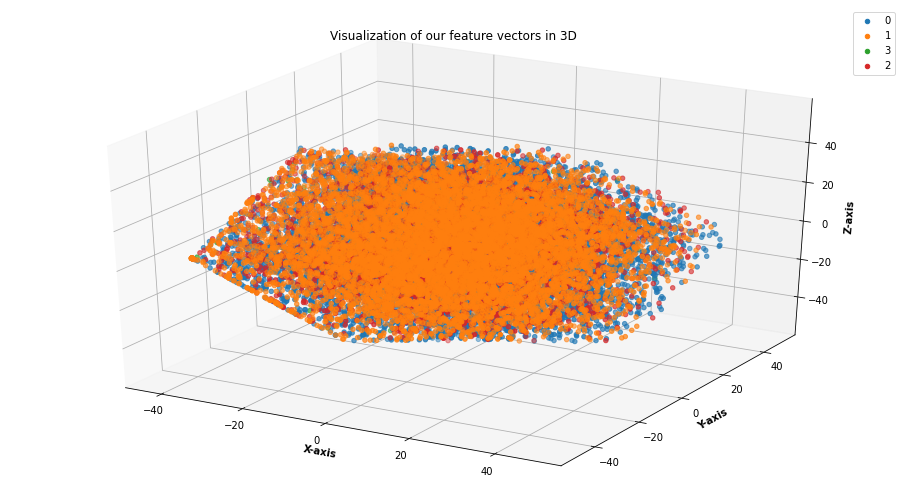

```python
# Let's visualize how the vectors will look like in a 3D dimensional space
fig = plt.figure(figsize=(16, 9))
ax = plt.axes(projection="3d")
ax.grid(b=True, color="grey", linestyle="-.", linewidth=0.3, alpha=0.2)

# Projecting our vectors into 3D space with PCA
pca = PCA(n_components=3)
coords_3d = pca.fit_transform(df_train_last.iloc[:, :-1])
for categ in df_train_last["target"].unique():
    ax.scatter(
        coords_3d[df_train_last["target"] == categ, 0],
        coords_3d[df_train_last["target"] == categ, 1],
        coords_3d[df_train_last["target"] == categ, 2],
        label=categ,
    )

plt.title("Visualization of our feature vectors in 3D")
ax.set_xlabel("X-axis", fontweight="bold")
ax.set_ylabel("Y-axis", fontweight="bold")
ax.set_zlabel("Z-axis", fontweight="bold")
plt.legend(loc="best")
plt.show()
```

# Classification models

- Target's distribution

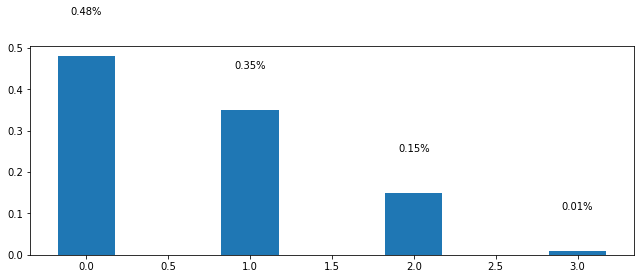

```python
plt.rcParams["figure.figsize"] = [9, 4]
plt.rcParams["figure.autolayout"] = True

x = df_train_last["target"].value_counts().keys()
y = np.around(
    df_train_last["target"].value_counts().tolist()
    / np.sum(df_train_last["target"].value_counts().tolist()),
    2,
)

width = 0.35
fig, ax = plt.subplots()

pps = ax.bar(x, y, width, align="center")

for p in pps:
    height = p.get_height()
    ax.text(
        x=p.get_x() + p.get_width() / 2,
        y=height + 0.10,
        s="{}%".format(height),
        ha="center",
    )

plt.show()
```

The class with label 3 represents less than 1% of the dataset, we're in case of unbalanced dataset

In this section, we'll train many models for multiclass classification. we'll first split our dataset into train and test

```python
# Shuffle train dataset
df_train_last = df_train_last.sample(frac=1).reset_index(drop=True)

# Split df_train into train and test datasets
X_train, X_test, y_train, y_test = train_test_split(
    df_train_last.iloc[:, :-1], df_train_last["target"], test_size=0.33, random_state=42
)
```

## Logistic Regression

```
Fitting 5 folds for each of 1 candidates, totalling 5 fits
```

```
{'multi_class': 'auto'}
              precision    recall  f1-score   support

           0       0.00      0.00      0.00      3917
           1       0.00      0.00      0.00      2973
           2       0.16      0.90      0.27      1277
           3       0.02      0.24      0.04        83

    accuracy                           0.14      8250
   macro avg       0.04      0.28      0.08      8250
weighted avg       0.02      0.14      0.04      8250
```

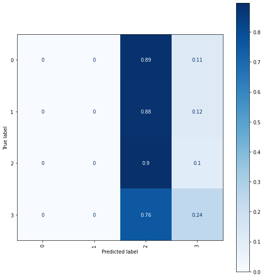

```python
# Logistic Regression params
LR_params = { "multi_class": ["auto"]}

# Defining class weights
weights = {0: 1, 1: 10, 2: 100, 3: 1000}

#  Grid search for Logistic regression model
lr = LogisticRegression(class_weight=weights)
lr_tuned = GridSearchCV(
    lr,
    param_grid=LR_params,
    scoring=make_scorer(f1_score, average="macro"),
    verbose=10,
    cv=5,
    n_jobs=-1,
)

# Start training the model
lr_tuned.fit(X_train, y_train)

# Get the best estimator
lr_best = lr_tuned.best_estimator_
y_test_hat = lr_best.predict(X_test)

# Print the best parameters
print(lr_tuned.best_params_)
print(classification_report(y_test, y_test_hat))

# Plot confusion matrix
fig, ax = plt.subplots(figsize=(8, 8))
plot_confusion_matrix(
    lr_best,
    X_test,
    y_test,
    cmap=plt.cm.Blues,
    normalize="true",
    ax=ax,
)
plt.xticks(rotation="vertical")
plt.show()
```

## SVM

```
Fitting 5 folds for each of 1 candidates, totalling 5 fits
```

```
{'C': 1.0, 'gamma': 'scale', 'kernel': 'rbf'}
              precision    recall  f1-score   support

           0       0.00      0.00      0.00      3917
           1       0.00      0.00      0.00      2973
           2       0.15      1.00      0.27      1277
           3       0.00      0.00      0.00        83

    accuracy                           0.15      8250
   macro avg       0.04      0.25      0.07      8250
weighted avg       0.02      0.15      0.04      8250
```

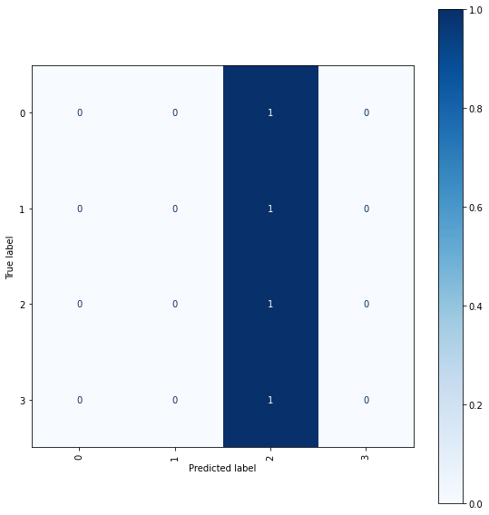

```python
# SVM Algorithm params
SVM_params = {"kernel": ["rbf"], "C": [1.0], "gamma": ["scale"]}

# Defining class weights
weights = {0: 1, 1: 10, 2: 100, 3: 1000}

# Start training the model
svm = SVC(class_weight=weights)
svm_tuned = GridSearchCV(
    svm,
    param_grid=SVM_params,
    scoring=make_scorer(f1_score, average="macro"),
    verbose=10,
    cv=5,
    n_jobs=-1,
)
svm_tuned.fit(X_train, y_train)

# Select the best estimator
svm_best = svm_tuned.best_estimator_
y_test_hat = svm_best.predict(X_test)

# Print the best model's parameters
print(svm_tuned.best_params_)
print(classification_report(y_test, y_test_hat))

# Plot the confusion matrix
fig, ax = plt.subplots(figsize=(8, 8))
plot_confusion_matrix(
    svm_best,
    X_test,
    y_test,
    cmap=plt.cm.Blues,
    normalize="true",
    ax=ax,
)

plt.xticks(rotation="vertical")
plt.show()
```

## Random Forest

```python
def get_weights(Y):
    """
    This function computes the penalty coefficients

    :param Y : the labels
    :return: the penalty coefficients : 1 for class 0, 10 for class 1, 100 for class 2 and 1000 for class 3
    """

    dict_weights = {0: 1, 1: 10, 2: 100, 3: 1000}
    return [dict_weights[Y.tolist()[i]] for i in range(len(Y))]
```

```
Fitting 5 folds for each of 1 candidates, totalling 5 fits
```

```
{'bootstrap': True, 'n_estimators': 1000, 'n_jobs': -1}
              precision    recall  f1-score   support

           0       0.74      0.89      0.81      3917
           1       0.72      0.66      0.69      2973
           2       0.70      0.42      0.52      1277
           3       0.50      0.02      0.05        83

    accuracy                           0.73      8250
   macro avg       0.66      0.50      0.52      8250
weighted avg       0.72      0.73      0.71      8250
```

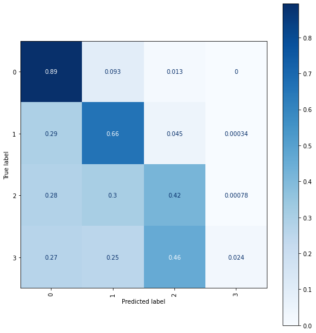

```python
# Random FOrest Algorithm params
RF_params = {"n_estimators": [1000], "bootstrap": [True], "n_jobs": [-1]}

# Start training the model
rdf = RandomForestClassifier()
rdf_tuned = GridSearchCV(
    rdf,
    param_grid=RF_params,
    scoring=make_scorer(f1_score, average="macro"),
    verbose=10,
    cv=5,
    n_jobs=-1,
)
rdf_tuned.fit(
    X_train,
    y_train,
    sample_weight=get_weights(y_train),
)

# Select the best estimator
rdf_best = rdf_tuned.best_estimator_
y_test_hat = rdf_best.predict(X_test)

# Plot the best model's parameters
print(rdf_tuned.best_params_)

print(classification_report(y_test, y_test_hat))
#f1_scores = f1_score(y_test, y_test_hat, average=None, labels=np.unique(y_test))
#print("----- f1 score : ", f1_scores)

# Plot the confusion matrix
fig, ax = plt.subplots(figsize=(8, 8))
plot_confusion_matrix(
    rdf_best,
    X_test,
    y_test,
    cmap=plt.cm.Blues,
    normalize="true",
    ax=ax,
)
plt.xticks(rotation="vertical")
plt.show()
```

```python
# save the random forest model
dump(rdf_best, open('rdf_best.pkl', 'wb'))
```

## Xgboost

```
Fitting 3 folds for each of 1 candidates, totalling 3 fits
{'learning_rate': 0.02, 'n_estimators': 1000, 'objective': 'multi:softmax'}
              precision    recall  f1-score   support

           0       0.99      0.37      0.54      3917
           1       0.73      0.55      0.63      2973
           2       0.30      0.91      0.45      1277
           3       0.08      0.63      0.14        83

    accuracy                           0.52      8250
   macro avg       0.52      0.61      0.44      8250
weighted avg       0.78      0.52      0.55      8250
```

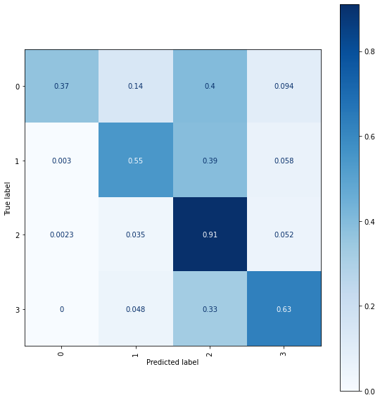

```python
# XGBoost Algorithm params
XG_params = {
    "learning_rate": [0.02],
    "n_estimators": [1000],
    "objective": ["multi:softmax"]
    #'tree_method': ["gpu_hist"]
}

# Grid search for XGBClassifier model
xgb_tuned = GridSearchCV(
    XGBClassifier(scale_pos_weight=10),
    param_grid=XG_params,
    scoring=make_scorer(f1_score, average="macro"),
    verbose=10,
    cv=3,
    n_jobs=-1,
)

# Start training the model
xgb_tuned.fit(X_train, y_train, sample_weight=get_weights(y_train))

# Select the best estimator, and its parameters
xgb_best = xgb_tuned.best_estimator_
y_test_hat = xgb_best.predict(X_test)

# Plot the confusion matrix
print(xgb_tuned.best_params_)
print(classification_report(y_test, y_test_hat))
fig, ax = plt.subplots(figsize=(8, 8))
plot_confusion_matrix(
    xgb_best, X_test, y_test, cmap=plt.cm.Blues, normalize="true", ax=ax
)
plt.xticks(rotation="vertical")
plt.show()
```

# Output result

We apply the processing steps using the process_dataset function and predict the probabilities using the loaded model.

```python
# Get the id column before processing df_test
df_id = df_test["id"]

# Processing df_test using process_dataset function
df_test = process_dataset(df_test)

# Load the random forest model
rdf = pickle.load(open("rdf_best.pkl", 'rb'))

# Predicted probabilities for each sample
predicted_proba = rdf.predict_proba(df_test)

# Create the output dataframe
df_result = pd.DataFrame(predicted_proba, columns = ["0", "1", "2", "3"])

# Add the id column
df_result = pd.concat([df_id, df_result], axis=1)
df_result
```

|  | id | 0 | 1 | 2 | 3 |
| --- | --- | --- | --- | --- | --- |
| 0 | cb7a4e0dd0777 | 0.687 | 0.193 | 0.098 | 0.022 |
| 1 | e78e3915f3e30 | 0.042 | 0.345 | 0.580 | 0.033 |
| 2 | 8e65ba155f983 | 0.803 | 0.118 | 0.062 | 0.017 |
| 3 | 701e90ca03ce2 | 0.891 | 0.051 | 0.040 | 0.018 |
| 4 | 768fefec8609a | 0.168 | 0.240 | 0.485 | 0.107 |
| ... | ... | ... | ... | ... | ... |
| 24995 | 3232bad9c00cc | 0.896 | 0.074 | 0.025 | 0.005 |
| 24996 | 7b178c38ad263 | 0.638 | 0.218 | 0.144 | 0.000 |
| 24997 | 5876ad905d4b4 | 0.518 | 0.438 | 0.039 | 0.005 |
| 24998 | 5921ef2921c68 | 0.817 | 0.130 | 0.042 | 0.011 |
| 24999 | d4152ad641c9f | 0.417 | 0.273 | 0.284 | 0.026 |

25000 rows × 5 columns

```python
df_result.to_csv("df_result.csv")
```